# Predicting Spotify Hits

Kuan-I Lu

2024-06-07

# Introduction

The goal of this project is to use machine learning tools to predict if a song is going to be a “hit” or not. A hit can be briefly defined as a song so popular that most people have heard of it and can sing along with. I will be using the Spotify million song data from Kaggle, which details will be provided in the following sections. Furthermore, I will be performing some EDA to visualize the properties our data set possesses, including distribution, correlation, and interaction of variables. Finally, I will implement multiple machine leaning models to find out the optimal model to make the intended prediction for this classification problem and test the performance with testing data.

## Inspiration and Motive

Not only do I enjoy listen to music, I also extended my passion of music into the realm of producing and song writing. As a fellow musician, I constantly have the question about the underlying pattern creating successful songs and artists. One of the main question asked is: What makes a song more popular than others? The common knowledge suggests that luck and randomness plays a significant role in the success of a song, since there is simply too many of them out there, and the audiences attention is a limited resource. However, is that actually the case? Maybe the success of a song is not completely random and maybe there are some patterns shared by the top songs that everybody likes. Maybe the lyrics matters a lot, or maybe the more upbeat a song is the popular it will be. These all are valid hypotheses, which is why methods of machine learning is introduced to solve problems like this, and we will be applying such methods.

Instead of asking “what makes a song popular” I want to change the way the question is delivered and ask instead “Will this song be the one? Will it become a hit?” The term “hit” is roughly identified as a song that is all over the media, where you can expect your friends to know it without introducing the song. Looking at the history of all songs, only a selected percent of songs can become a “hit” and , unfortunately, a larger portion of songs are classified as a “flop”, which is the opposite of a hit. Flops are songs which barely anyone has heard of it. The rest of the songs, which have some level of popularity but did not make it to the top charts, would be considered as a “regular” performing song.

I want to help other musicians that are uncertain about their songs’ success to build a model to predict, and give a general idea, of the popularity potential of their product. With this tool, artists can be provided a guideline and prediction of the projected performance of their music, and the case where the model produces a positive result indicates that the artist is on the right track and has a strong potential of becoming the next rock star like Taylor Swift, Post Malone, Kendrick Lamar, or whoever the big names you can think of.

## Data Description

- **Kaggle, Spotify 1 million tracks dataset, Amitansh Joshi, Vedent Das, Amit Parolkar**

  This data set consists of around a million observations on Spotify, one of the world’s leading music streaming platforms. The data set is very comprehensive which includes multiple parameters such as name of song, name of artist, popularity, energy, dancability, genre, and more. The observations are across a long period of time, from 2000 to 2023, recording all the songs that are available on the platform, no matter popular or not. The way `popularity` of a song is calculated is based on the number of plays it has had, and how recent those plays are at the time of observation. Spotify uses a complicated algorithm to calculate the exact numeric value of `popularity`, and for the purpose of this project, we care less about the value of `popularity` but the order and the quantile of it. Based on the observation of the `popularity` variable, we will create a product variable `pop`, which is a nominal variable that takes the value “hit”, “regular”, or “flop”. Using the information of the data set, we wil try to predict the value of `pop` given the multiple predictors. More details about the data set can be found here: [Spotity 1 million tracks](https://www.kaggle.com/datasets/amitanshjoshi/spotify-1million-tracks)
- **Kaggle, Music artists popularity, PIOTR**

  This data set consists of over 1.3 millions of artists and their information up to year 2019. One of the most important information includes the popularity of the artist in terms of number of listeners on last.fm. I will use this as an indicator to put artists in a tier list, classifying the popularity of artists in multiple tiers. This would make it easier for us to take into account the effect of the popularity of the artist have on the potential if a song is going to be a hit or not. With this information and the new classification, we can avoid making redundant dummy variables for `artist_name` and it’ll help for better prediction and interpretation. The details of this data set can be found here: [Music artists popularity](https://www.kaggle.com/datasets/pieca111/music-artists-popularity)

# Exploring Our Data

Now that we have an understanding of the goals of this project, let’s load the data set and explore them briefly. We will clean the data and perform EDA with some visualizations.

## Tidying the Data

Even though the data set is pretty comprehensive, we still want to take a look at the data set as well as create a classification variable to meet the goal of this project.

### Loading the Data

Let’s load the data and see if there are any initial actions we need to take.

```r
library(finalfit)
library(tidyverse)
library(tidymodels)
library(ggplot2)
library(dplyr)
library(corrplot)
library(themis)
library(kknn)
library(ranger)
library(vip)

song_data = read_csv("data/spotify million songs/spotify_data.csv")
artist_data = read_csv("data/artist popularity/artists.csv")
```

The value of popularity of the songs are on a scale from 0 to 100. Here, to match the purpose of this project, we are going to make another variable `pop` which labels the top few percent of the songs as `hit`, the last few percent of the songs as `flop`, and the rest as `regular`. The cut of these values will be determined based on the distribution of the variable `popularity`.

### Create classification variable `pop`

Let’s look at the distribution of our output variable, `popularity`, and decide on cutoffs to determine the three classifications in `pop`.

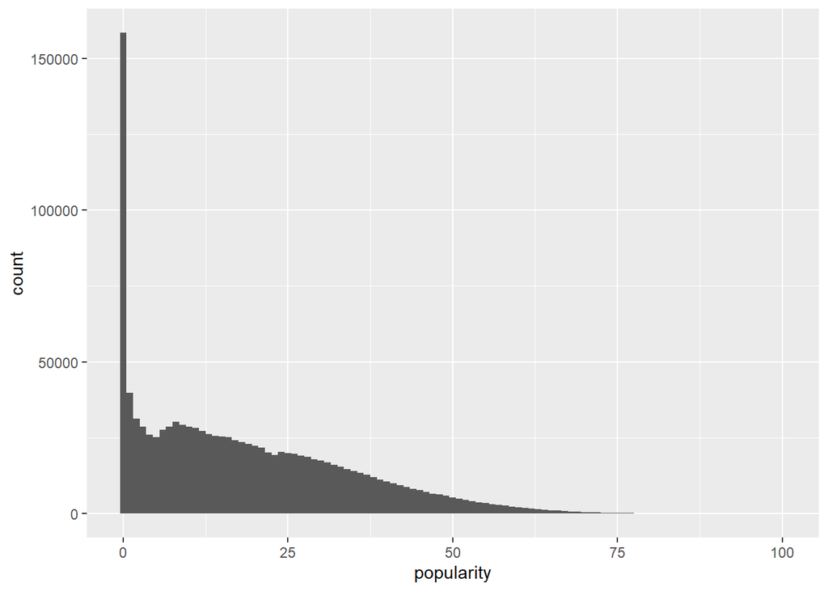

```r
#plot the distribution of popularity
song_data %>%  ggplot(aes(x = popularity)) + geom_histogram(binwidth = 1)
```

Notice that the curve follows a bimodal distribution and the value of 0 has the highest peak in the `popularity` distribution. This reflects the phenomenon of the current music market, which is that a good portion of the songs have zero streams and are never heard of. Knowing this fact, let’s take a deeper look at the observations with popularity 0.

```r
#number of observations with popularity 0
total_unheard = nrow(song_data %>% filter(popularity == 0))

#number of total observations
total_songs = nrow(song_data)

#portion of unheard songs
total_unheard/total_songs
```

```
## [1] 0.1365718
```

Realize that over 13.5% of songs are never heard of, which is a significant proportion. The problem here is, if we only classify the unheard songs as “flops”, then we neglected the songs that has streams but didn’t perform well. We want a song being a hit or flop also be discussed among those that has exposure, too. So, to determine if a song is a hit or flop, we will determine cuts based on the non-zero popularities.

Here, we introduce some subjective concepts. For example, if a song has streams but has a average popularity, it’s not a flop, it’s just a less popular song. If a song has exposure but still falls in the bottom 20% percentage in terms of popularity, then that’s pretty bad, so the song would be a “flop”. With that being said, we consider songs with 0 popularity and the bottom 20% of the rest as flops. To calculate a quantile as cutoff, we take the 13.657%, and 20% of the remaining (100-13.657)%. That is, $0.13657 + 0.2 \times (1-.13657) = 0.309256$. Around 30.93% percent of the least popular would be defined as flops.

On the other hand, being a hit should have a higher bar. Assuming the 1,159,764 song are all the songs known in the market, only the top 0.5% should be considered as “hits”. Since $1,159,764 \times 0.005 \approx 5798$ we’re granting the top 5798 songs to be “hits”. This is a relatively generous range. Think about this, how many songs that you can name between 2000 and 2023 that you can sing along with your friends?

With the aforementioned cutoffs, we make a new variable `cut` denoting the classification of popularity of a song. Here we also visualize the distribution of the three classes to ensure they follow the cutoffs we defined.

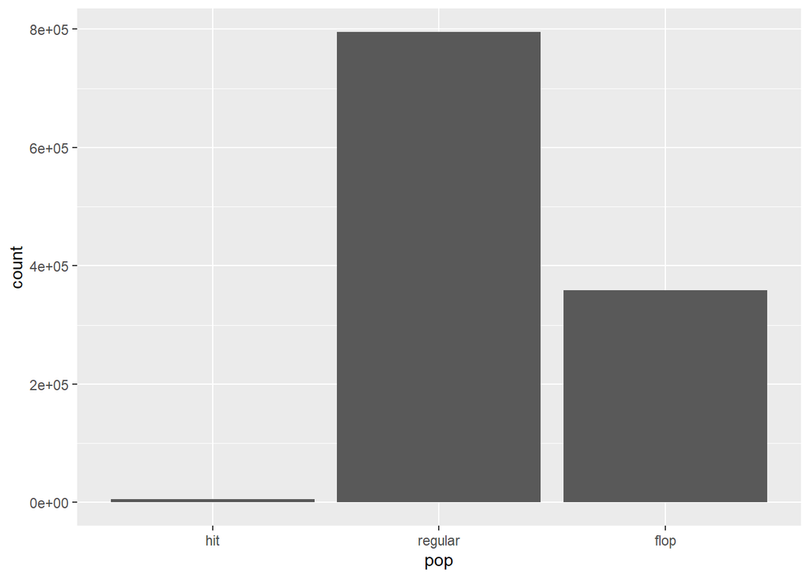

```r
#calculate quantile of popularity
song_data = song_data %>%
  mutate(popularity_quantile = ntile(popularity, 10000))

#create a new variable pop
song_data = song_data %>%
  mutate(pop = ifelse(popularity_quantile <= 3093, "flop",
                      ifelse(popularity_quantile <= 9950, "regular", "hit")))

#change the order of classes
song_data$pop = factor(song_data$pop, levels = c("hit", "regular", "flop"))

#create bar pot of pop
song_data %>% ggplot(aes(x = pop)) + geom_bar()
```